# The impact of flood occurrences on property sales: the case of São Paulo, Brazil

Author

Bruno Azuma Balzano - nº usp: 10698043

Published

August 17, 2026

# 1 Introduction

Since the 2000’s, the occurrence of natural disasters has increased in incidence and media coverage (Daniel, Florax, and Rietveld 2009). Among these disasters, floods are particularly proeminent, causing significant human and material losses. One of the most impacting material losses for families is the destruction of their homes. As so, several papers have studied the impact of floods on house prices, mostly by evaluating a risk discount based on the presence of the house within a 100-year floodplain (Daniel, Florax, and Rietveld 2009; Zhang and Leonard 2019). However, the majority of these studies have been conducted in the US or other developed countries from the Global North, and they also rely on some hedonic regression models and rarely make use of panel data. In this paper, I build upon a model proposed by Krainer (2001), which show that a) house prices, liquidity and sales depend simultaneously on the housing service flow, and b) the house liquidity can vary for other conditions than financial constraints, including amenities or local shocks. Given that, I propose a census tracts panel data model to evaluate the impact of floods events on the volume of residential house sales for the city of São Paulo, Brazil. This study aims to contribute to the literature on the economic impact of floods in developing countries, particularly in Latin America, by answering if flood events have a significant impact on the volume of residential house sales in São Paulo, Brazil, and if so, to what extent.

Daniel, Florax, and Rietveld (2009) provides an extensive meta-analysis of the literature on the impact of floods on house prices in the US up to the 2000’s. The authors make use of 19 studies and 117 point estimates to evaluate the impact of flood risk and flood events on house prices. They find that the average impact of flood risk on house prices is a discount of 0.6% and the actual occurrence of a flood event enhance the implicit price of flooding, but with a negligible effect. Lima and Barbosa (2019) address the impact of natural disasters from another perspective. They evaluate the impact of flooding on the GDP of Brazilian municipalities at the State of Santa Catarina. The advantage of this approach is that it allows to evaluate the impact of floods on the local economy based on a difference-in-differences approach, but it does not allow to evaluate the impact of floods on specific markets, such as the housing market. Here, I propose an event study approach to evaluate the impact of floods on the volume of residential house sales in São Paulo, Brazil, based on all the transactions that occurred in the city between 2023 and 2025. This allows the evaluation of very local effects of floods on the housing market, which is not possible with a more aggregated approach. The main contribution of this paper is to provide a more comprehensive understanding of the impact of floods on the housing market at intra-urban level in a developing country, which can inform policy decisions and risk management strategies for homeowners, buyers, and policymakers.

The rest of the study is organized as follows. Section 2 presents the methodology used to evaluate the impact of floods on the volume of residential house sales in São Paulo, Brazil. Section 3 presents the data used in this study, including the sources and the variables. Section 4 presents the results of the analysis, including the main findings and their implications. Section 5 presents some sensitivity analyses to evaluate the robustness of the results. Finally, Section 6 summary the findings and concludes the study.

# 2 Methodology

As mentioned in the introduction, I propose an event study approach to evaluate the impact of floods on the volume of residential house sales in São Paulo, Brazil. As stated by Krainer (2001), the volume of house sales can be affected by several factors, including the housing service flow, the liquidity of the housing market, and local shocks. In this study, I focus on the impact of floods as a local shock that can affect the volume of residential house sales in São Paulo. The flooding occurences can be considered as a negative ammenity shock that can affect the liquidity of the local housing market, and consequently, the volume of house sales. From the empirical perspective, I propose a difference-in-differences with multiple periods approach to evaluate the impact of floods on the volume of residential house sales in São Paulo. The difference-in-differences approach allows to evaluate the impact of floods on the volume of house sales by comparing the changes in the volume of house sales in flooded areas with the changes in the volume of house sales in non-flooded areas before and after the occurrence of floods, while also controlling for unobserved characteristics of the census tracts and time fixed effects. The multiple periods approach allows to evaluate the impact of floods on the volume of house sales over time, which is important to capture the dynamic effects of floods on the housing market. The main assumption of the difference-in-differences approach is that in the absence of floods, the changes in the volume of house sales in flooded areas would have been similar to the changes in the volume of house sales in non-flooded areas. This assumption can be evaluated by comparing the pre-treatment trends in the volume of house sales between flooded and non-flooded areas. If the pre-treatment trends are similar, then it can be assumed that the difference-in-differences approach provides a valid estimate of the impact of floods on the volume of residential house sales in São Paulo.

One important assumption to be noted is that for all of the models it is assumed that, once a flood occurs, the census tract is considered to be flooded for all subsequent periods. This assumption is based on the fact that floods can have long-lasting effects on the local housing market through the perception of risk by the agents, both local residents and real state agents. This assumption is also supported by the literature on the impact of floods on house prices, which shows that the occurrence of floods can have a persistent effect on the implicit price of flooding (Daniel, Florax, and Rietveld 2009), although the effect is negligible. In this study, I assume that the occurrence of floods can have a persistent effect on the volume of residential house sales in São Paulo, which is consistent with the literature on the impact of floods on house prices.

I evaluated four reduced models. Two of them are based on the event study proposed by Callaway and Sant’Anna (2021), one without and one with covariates. The main difference between these two models is the parallel trends assumption, which becomes a conditional parallel trends assumption when covariates are included in the model. These models propose an alternative way to aggregate the group-time average treatment effects (ATT) to obtain, among other possible results, the average treatment effect for being treated to a varying number of periods. The other two models are based on the event study proposed by Butts (2021), one without and one with covariates. This is done considering that the effect of a flood occurrence may not be constrained to a single tract, but may also have a spillover effect on the surrounding tracts. The main difference between these two models is also the parallel trends assumption, which becomes a conditional parallel trends assumption when covariates are included in the model. Also, Butts (2021) proposes that the imediate neighborhood of a treated unit may also be affected by the treatment, leading to a bias on the estimation of the treatment effect.

The set of covariates used in the models derive from previous work on the impact of floods on house prices (Daniel, Florax, and Rietveld 2009; Chakraborty et al. 2014; Zhang 2016; Zhang and Leonard 2019; Rajapaksa et al. 2017). The covariates were adapted to the context of São Paulo, Brazil, and include the distance to the nearest park, the distance to the nearest water body, the percentage of black and brown people, the percentage of indigenous people, the distance to the Central Business District (CBD), the total residences, and the average income for each census tract. These covariates are used to control for observed characteristics of the census tracts that may affect the volume of residential house sales, and to evaluate the conditional parallel trends assumption.

For all of these models, tracts that suffered from flooding before the period of analysis were excluded from the sample, as they are considered to be already treated. The evaluation was made from 2023 to 2025 so that the available data from the GeoSampa allowed to remove the census tracts that suffered from flooding 10 years before the period of analysis, assuming that this is a sufficient time to consider that the effect of flooding on the volume of residential house sales is negligible. On the sensitivity analysis, I also evaluated the models considering additional restrictions on the untreated group.

# 3 Data

There are several sources of data used in this study. The outcome variable is the volume of residential house sales, which is obtained from the São Paulo City Hall’s database about the tax on the transfer of real estate property (ITBI). The ITBI database provides information about all the transactions that occurred in the city of São Paulo with the address of the property, the date of the transaction, and the declared value of the transaction. The ITBI database was geocoded with the geocodebr[^1] package, which allows to obtain the coordinates of the properties based on their addresses. The geocoded data was then aggregated at the census tract level to obtain the volume of residential house sales for each census tract in each month. The census tracts geographical data was obtained from the geobr package[^2], which provides the geographical boundaries of the census tracts, among several other geographical data, for Brazil. The census tracts geographical data was used to aggregate the geocoded ITBI data at the census tract level. The volume of residential house sales was then calculated as the percentage of transacted residences in each census tract in each quarter, as the quarter is more climate stable than the month and more correlated with the occurrence of floods, which is the treatment variable.

The treatment variable is the occurrence of floods, which is obtained from the GeoSampa, São Paulo Digital Map[^3]. The GeoSampa provides information about the occurrence of floods in the city of São Paulo since 2013, including the date of the occurrence and the geographical location of the flooded location as a point. The occurrence of floods was then calculated as a binary variable, which takes the value of 1 if there was at least one flood occurrence in the census tract in the quarter, and 0 otherwise.

Lastly, the covariates used in the models are obtained from two sources. The first is the forementioned GeoSampa, which provides information about the location of administrative districts, parks and water bodies in the city of São Paulo. The second source is censobr package[^4], which provides census data for Brazil, including information about the population, total residences, and the average income for each census tract. The covariates used in the models are the distance to the nearest park, the distance to the nearest water body, the percentage of black and brown people, the percentage of indigenous people, the total residences, and the average income for each census tract. The distance to the Central Business District (CBD) was calculated as the distance from each census tract to the District of Sé, which holds the larger number of formal jobs in the city of São Paulo for the year of 2021[^5].

The final dataset used in this study is a panel data of 24,339 census tracts in the city of São Paulo, Brazil, from 2023 to 2025, with a total of 292,068 observations. The dataset includes the volume of residential house sales, the occurrence of floods, and the covariates for each census tract in each quarter. The transactions data were filtered to include only horizontal and vertical residential properties and only complete property transactions (which excludes partial sales, such as the sale of a fraction of a property). The final dataset used in this study is available in the supplementary material and the Azuma (2026).

# 4 Results

Here, I present the results of the analysis, including the main findings and their implications. The results are presented in two parts. The first part presents the results of the event study proposed by Callaway and Sant’Anna (2021), both without and with covariates. The second part presents the results of the event study proposed by Butts (2021), both without and with covariates. The results are presented in terms of the average treatment effect for being treated to a varying number of periods, which allows to evaluate the dynamic effects of floods on the volume of residential house sales in São Paulo.

The Figure 1 shows the results of the Callaway and Sant’Anna (2021) models for periods since flooding, both without and with covariates. The results doesn’t show any significative effect of the occurence of flooding on a census tract. The pre-treatment trends are similar between the treated and control groups both with and without covariates, which helps to support the parallel trends assumption on both cases.

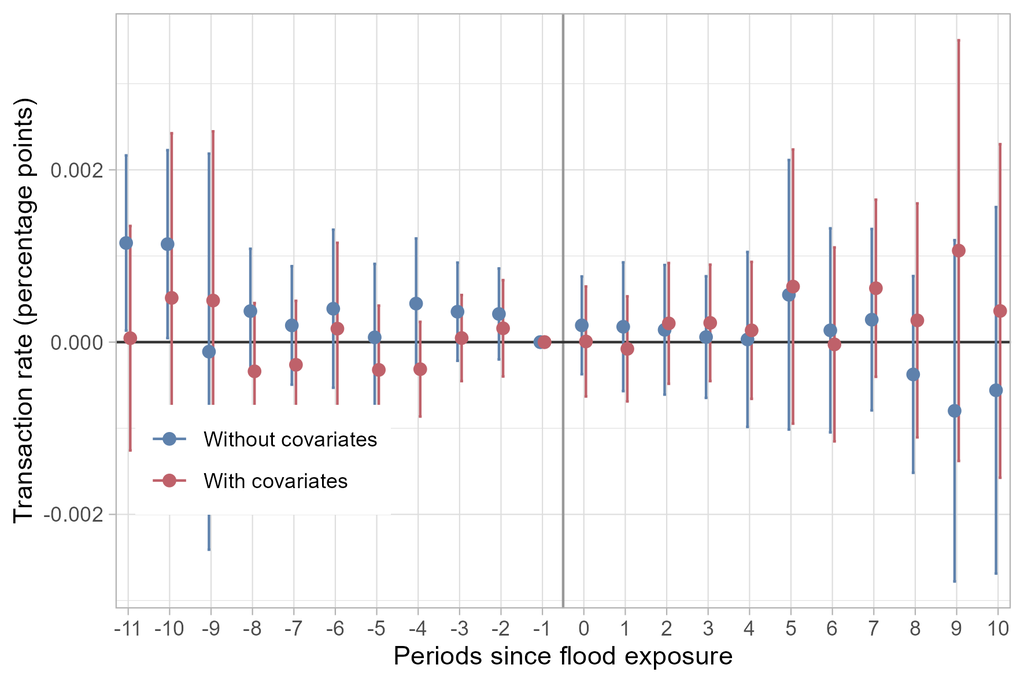

Figure 1: Results of the Callaway and Sant’Anna (2021) models for periods since flooding.

The Figure 2 shows the results of the Butts (2021) models for rings of 0-50m, 50-100m, 100-200m, and 200-400m, without covariates. The results also doesn’t show significative effects of the occurence of flooding on a census tract or its surrounding tracts for most of the periods since flooding, although there are some significative effects for the treatment and 0-50m ring for some periods. In any case, the point estimates are very close to zero, which suggests that the occurrence of flooding has a negligible effect on the volume of residential house sales in São Paulo. The pre-treatment trends are also similar between the treated and control groups, which helps to support the parallel trends assumption on both cases.

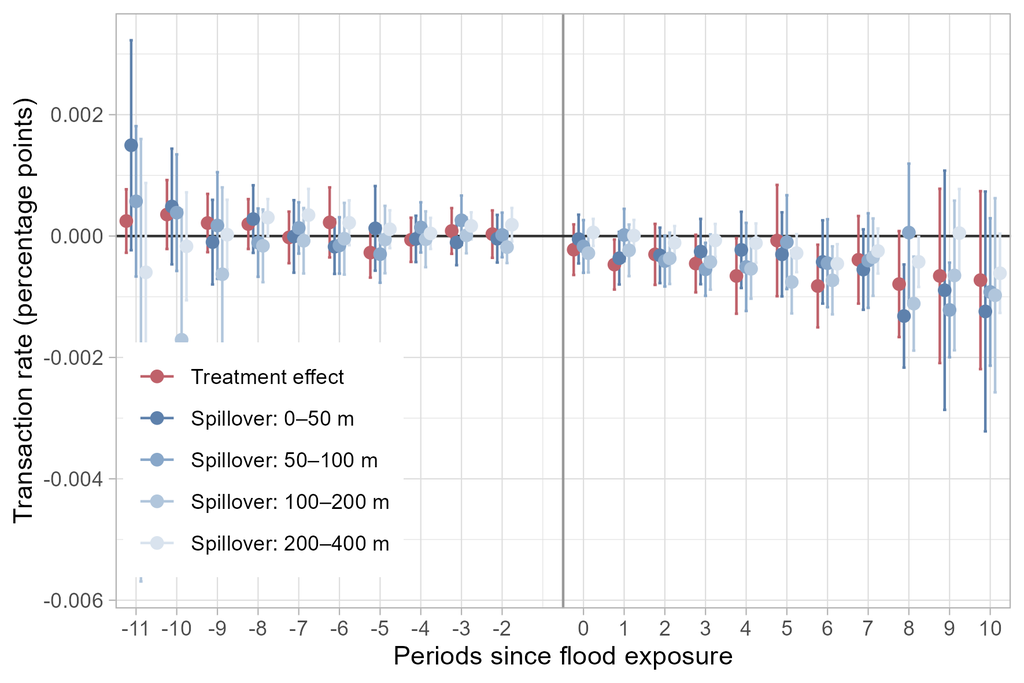

Figure 2: Results of the Butts (2021) without covariates for rings of 0-50m, 50-100m, 100-200m, 200-400m.

The Figure 3 shows the results of the Butts (2021) models for rings of 0-50m, 50-100m, 100-200m, and 200-400m, with covariates. The results also doesn’t show significative effects of the occurence of flooding on a census tract or its surrounding tracts for any of the periods since flooding. The pre-treatment trends are also similar between the treated and control groups, which helps to support the parallel trends assumption on both cases.

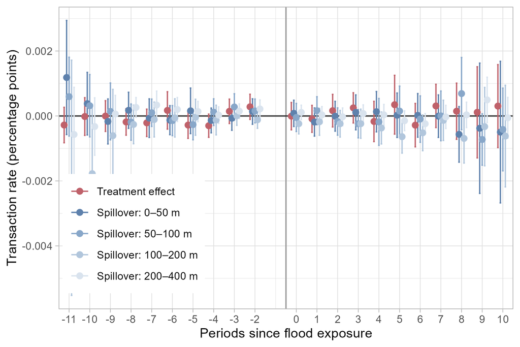

Figure 3: Results of the Butts (2021) with covariates for rings of 0-50m, 50-100m, 100-200m, 200-400m.

The above results suggest that the occurrence of flooding has a negligible effect on the volume of residential house sales in São Paulo, both for the treated census tracts and their surrounding tracts. This is consistent with the literature on the impact of floods on house prices, which shows that the occurrence of floods can have a persistent effect on the implicit price of flooding, but with a negligible effect (Daniel, Florax, and Rietveld 2009). The results also suggest that the parallel trends assumption holds for both models, which supports the validity of the difference-in-differences approach used in this study.

# 5 Sensitivity Analysis

For sensivity analysis, two approaches were taken. The first was to evaluate the parallel trends assumption in more details, as suggested by Roth et al. (2023). The second was to evaluate the robustness of the results by restricting the untreated group to census tracts that are more similar to the treated group in terms of their characteristics. The results of the sensitivity analysis are presented below.

As the only model with some significative effects was the Butts (2021) without covariates, I evaluated the parallel trends assumption for this model in more details. The results are presented in Figure 4 show the Relative Magnitudes test proposed by Rambachan and Roth (2023) for the Butts (2021) without covariates. The results show that a) although there are significative effects for some periods, the average treatment effect for being treated is not significant, and b) these effects do not hold in case of a small violation of the parallel trends assumption based on the pre-treatment trends. This strengthens the conclusion that the significative effects found for some periods are not robust. The remaining models were evaluated for the parallel trends assumption, but the results are not shown here as they do not show any significative effects for any of the periods since flooding.

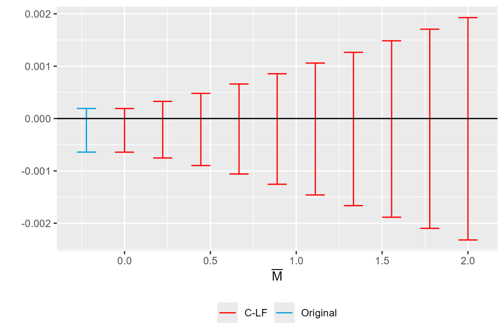

Figure 4: Results of the Rambachan and Roth (2023) Relative Magnitudes for the Butts (2021) without covariates.

Besides this test, two additional tests were performed to evaluate the robustness of the results. The first was to restrict the untreated group to census tracts that are more similar to the treated group in terms of their observed characteristics. The second was to restrict the untreated group to census tracts that are closer to any previous flooding occurrence, as these tracts are more likely to share also unobserved characteristics with the treated group.

For both the Callaway and Sant’Anna (2021) and Butts (2021) models, a logit model with the treatment as the dependent variable and the covariates as independent variables was estimated, and the predicted probabilities of being treated were used to restrict the untreated group to census tracts with at least a 10% probability of being treated. This, however, forced the previous exclusion of tracts with missing data for any of the covariates, which reduced the sample size. Additionally, the Butts (2021) models were also estimated using a 2 stage DiD approach, where a first stage is a logit model is used to remove the bias cited in Callaway and Sant’Anna (2021).[^6] For this reason, the results of the Butts (2021) model with covariates are not shown here, as they are not comparable with the other models. The results of the sensitivity analysis are presented below.

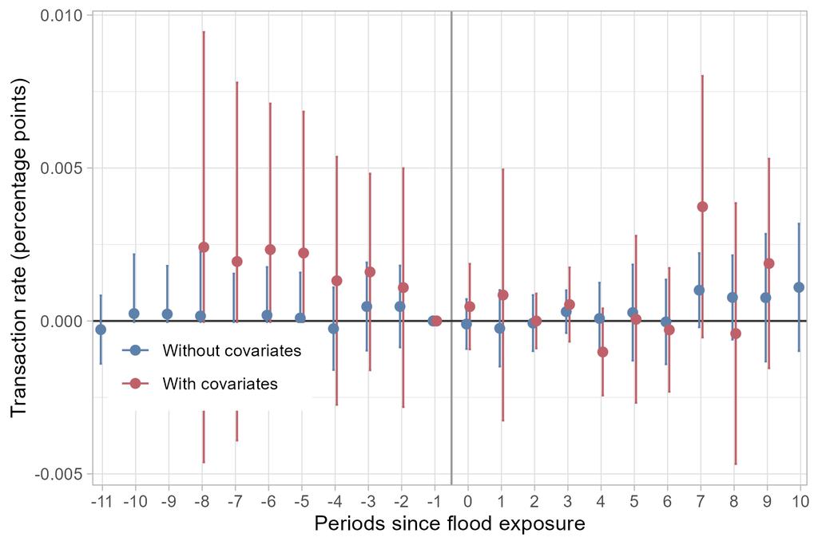

Figure 5: Results of the Callaway and Sant’Anna (2021) models for periods since flooding.

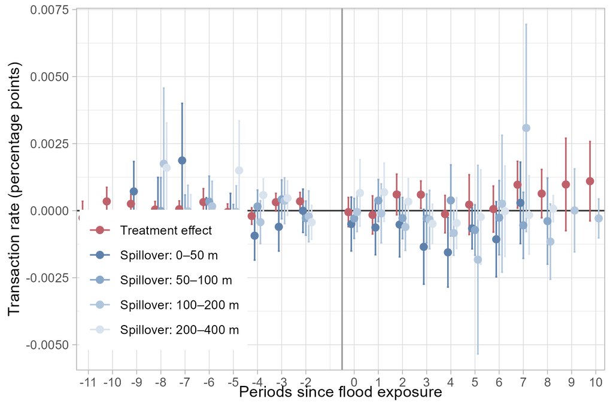

Figure 6: Results of the Butts (2021) without covariates for rings of 0-50m, 50-100m, 100-200m, 200-400m.

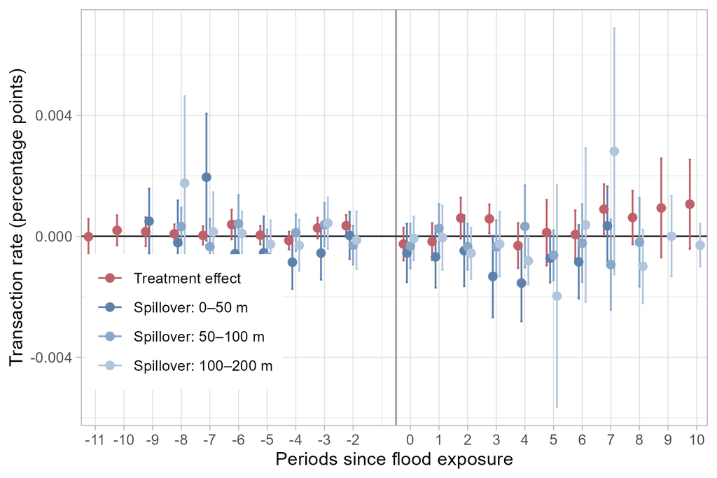

Figure 7: Results of the Butts (2021) without covariates for rings of 0-50m, 50-100m, 100-200m.

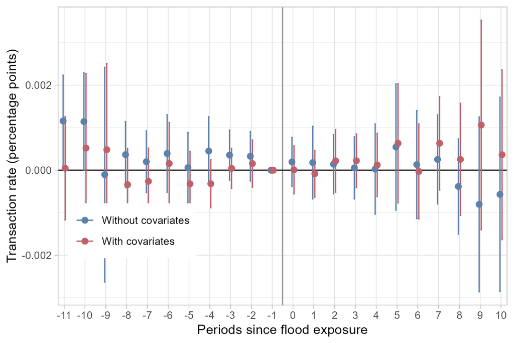

Figure 8: Results of the Callaway and Sant’Anna (2021) wit and withhout covariates.

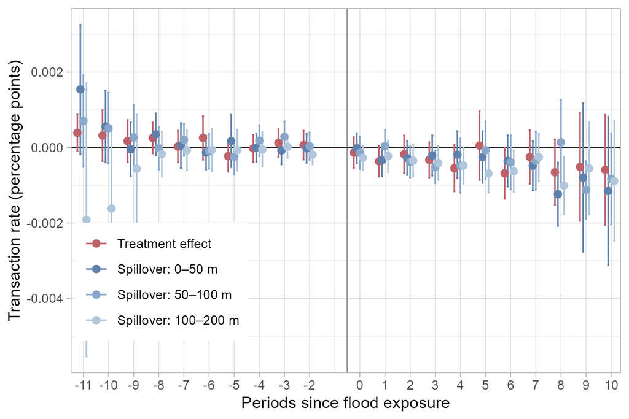

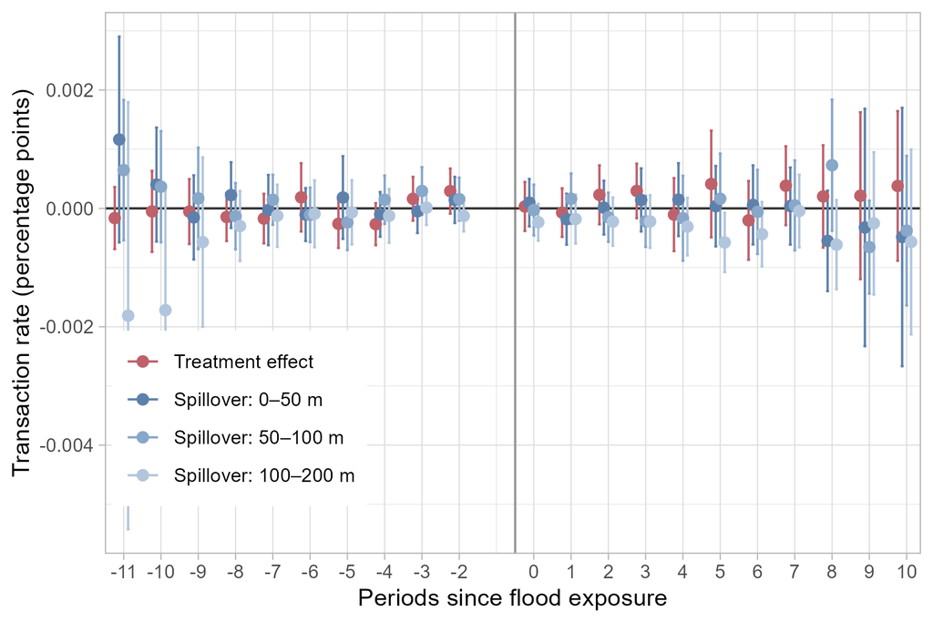

# 6 Conclusions

This study evaluated the impact of floods on the volume of residential house sales in São Paulo, Brazil, using an event study approach based on difference-in-differences with multiple periods. The relevance of the topic resides in the fact that floods are a common natural disaster that can have significant economic and social impacts, particularly in poorer urban regions of developing countries, and also in the fact that the natural disasters are increasing in incidence and impact. The previous literature on the impact of floods on house prices shows stated that the risk of flooding is more relevant than the actual occurrence of flooding, and that the occurrence of flooding has a negligible effect on the implicit price of flooding (Daniel, Florax, and Rietveld 2009). However, most of the previous literature is based on data from developed countries, and there is a lack of studies evaluating the impact of floods on the housing market in developing countries, particularly in Latin America. Besides that, the previous literature is mostly based on hedonic regression models or repeated cross-section data, which limits the causal evaluation of these impacts. In this study, I proposed a census tracts panel data model to evaluate the impact of floods on the volume of residential house sales in São Paulo, Brazil, which allows to evaluate the causal impact of floods on the housing market in a developing country.

Four models were evaluated, two based on the event study proposed by Callaway and Sant’Anna (2021), and two based on the event study proposed by Butts (2021). The results of the analysis show that the occurrence of flooding has a negligible effect on the volume of residential house sales in São Paulo, both for the treated census tracts and their surrounding tracts. This is consistent with the literature on the impact of floods on house prices, which shows that the occurrence of floods can have a persistent effect on the implicit price of flooding, but with a negligible effect (Daniel, Florax, and Rietveld 2009). The results also suggest that the parallel trends assumption holds for both models, which supports the validity of the difference-in-differences approach used in this study. It could be beneficial to evaluate the impact of floods on the price of residential house sales in São Paulo, Brazil, as most of the previous literature is based on the impact of floods on house prices. However, the combination of census tracts and quarterly data would not allow to evaluate the impact of floods on house prices, as the number of transactions in each census tract in each quarter is too small to provide a reliable estimate of the average price of residential house sales. Future studies could try to evaluate the impact of floods on house prices in São Paulo, Brazil, using a different approach, such as a hedonic regression model or a repeated cross-section data model, or different aggregations.

## 7 References

Azuma, Bruno. 2026. “Flood-House-Trading.” GitHub. https://github.com/brunoazuma/flood-house-trading.

Butts, Kyle. 2021. “Difference-in-Differences Estimation with Spatial Spillovers.” https://doi.org/10.48550/ARXIV.2105.03737.

Butts, Kyle, and John Gardner. 2022. “Did2s: Two-Stage Difference-in-Differences.” *The R Journal* 14 (3): 162–73. https://doi.org/10.32614/rj-2022-048.

Callaway, Brantly, and Pedro H. C. Sant’Anna. 2021. “Difference-in-Differences with Multiple Time Periods.” *Journal of Econometrics* 225 (2): 200–230. https://doi.org/10.1016/j.jeconom.2020.12.001.

Chakraborty, Jayajit, Timothy W. Collins, Marilyn C. Montgomery, and Sara E. Grineski. 2014. “Social and Spatial Inequities in Exposure to Flood Risk in Miami, Florida.” *Natural Hazards Review* 15 (3): 04014006. https://doi.org/10.1061/(ASCE)NH.1527-6996.0000140.

Daniel, Vanessa E., Raymond J. G. M. Florax, and Piet Rietveld. 2009. “Flooding Risk and Housing Values: An Economic Assessment of Environmental Hazard.” *Ecological Economics* 69 (2): 355–65. https://doi.org/10.1016/j.ecolecon.2009.08.018.

Krainer, John. 2001. “A Theory of Liquidity in Residential Real Estate Markets.” *Journal of Urban Economics* 49 (1): 32–53. https://doi.org/10.1006/juec.2000.2180.

Lima, Ricardo Carvalho De Andrade, and Antonio Vinícius Barros Barbosa. 2019. “Natural Disasters, Economic Growth and Spatial Spillovers: Evidence from a Flash Flood in Brazil.” *Papers in Regional Science* 98 (2): 905–25. https://doi.org/10.1111/pirs.12380.

Pereira, Rafael H. M., and Rogério J. Barbosa. 2026a. *Censobr: Download Data from Brazil’s Population Census*. https://CRAN.R-project.org/package=censobr.

Pereira, Rafael H. M., and Rogério Jerônimo Barbosa. 2026b. *Geobr: Download Official Spatial Data Sets of Brazil*. https://CRAN.R-project.org/package=geobr.

Pereira, Rafael H. M., Daniel Herszenhut, and Gabriel Garcia de Almeida. 2026. *Geocodebr: Geolocalização de Endereços Brasileiros*. https://CRAN.R-project.org/package=geocodebr.

Prefeitura do Município de São Paulo. 2026a. “GeoSampa: Mapa Digital Da Cidade de São Paulo.” https://geosampa.prefeitura.sp.gov.br/.

———. 2026b. “Observatório Do Trabalho de São Paulo.” Secretaria Municipal de Desenvolvimento Econômico e Trabalho. https://observatoriodotrabalho.prefeitura.sp.gov.br/.

Rajapaksa, Darshana, Min Zhu, Boon Lee, Viet-Ngu Hoang, Clevo Wilson, and Shunsuke Managi. 2017. “The Impact of Flood Dynamics on Property Values.” *Land Use Policy* 69 (December): 317–25. https://doi.org/10.1016/j.landusepol.2017.08.038.

Rambachan, Ashesh, and Jonathan Roth. 2023. “A More Credible Approach to Parallel Trends.” *The Review of Economic Studies* 90 (5): 2555–91. https://doi.org/10.1093/restud/rdad018.

Roth, Jonathan, Pedro H. C. Sant’Anna, Alyssa Bilinski, and John Poe. 2023. “What’s Trending in Difference-in-Differences? A Synthesis of the Recent Econometrics Literature.” *Journal of Econometrics* 235 (2): 2218–44. https://doi.org/10.1016/j.jeconom.2023.03.008.

Zhang, Lei. 2016. “Flood Hazards Impact on Neighborhood House Prices: A Spatial Quantile Regression Analysis.” *Regional Science and Urban Economics* 60 (September): 12–19. https://doi.org/10.1016/j.regsciurbeco.2016.06.005.

Zhang, Lei, and Tammy Leonard. 2019. “Flood Hazards Impact on Neighborhood House Prices.” *The Journal of Real Estate Finance and Economics* 58 (4): 656–74. https://doi.org/10.1007/s11146-018-9664-1.

## Footnotes

[^1]: See Pereira, Herszenhut, and Almeida (2026).
[^2]: See Pereira and Barbosa (2026b).
[^3]: See Prefeitura do Município de São Paulo (2026a).
[^4]: See Pereira and Barbosa (2026a).
[^5]: See Prefeitura do Município de São Paulo (2026b). In the year of 2022, the District with the largest number of formal jobs in the city of São Paulo was the District of Brás with 420,022 formal jobs. However, the previous and following years, the District of Brás never had more than 100,000 formal jobs, which suggests that the number of formal jobs in the District of Brás in 2022 is an outlier. So I considered the year of 2021, when the District of Sé had the largest number of formal jobs in the city of São Paulo with 684,162 formal jobs.
[^6]: For further details, check Butts and Gardner (2022).